# Customer Churn Prediction

Gyujin Seo

2022-08-07

# 1 Introduction

## 1.1 Problem Statement

Churn rate is the number of new customers compared to the number of churning customers. This is important because the cost of acquiring new customers is much greater than the cost of retaining existing ones. Therefore, if existing customers who are likely to churn can be identified and prevented in advance, the effect can be greater than simply acquiring more new customers. In addition, if the customer churn rate is accurately predicted, the customer lifetime value (CLV) and return on marketing investment can also be calculated more accurately, which in turn helps to make the right decision.

## 1.2 Goal

For the stability of the company’s financial problems, create a model to predict what customer has a high risk of leaving the bank’s credit card services.

## 1.3 Load libraries

## 1.4 Load the data

### Data Frame Summary

#### data

**Dimensions:** 10127 x 21  
**Duplicates:** 0

| No | Variable | Stats / Values | Freqs (% of Valid) | Graph | Valid | Missing |
| --- | --- | --- | --- | --- | --- | --- |
| 1 | CLIENTNUM [integer] | Mean (sd) : 739177606 (36903784) min < med < max: 708082083 < 717926358 < 828343083 IQR (CV) : 60106763 (0) | 10127 distinct values |  | 10127 (100.0%) | 0 (0.0%) |
| 2 | Attrition_Flag [character] | 1. Attrited Customer 2. Existing Customer | 1627 (16.1%) 8500 (83.9%) |  | 10127 (100.0%) | 0 (0.0%) |
| 3 | Customer_Age [integer] | Mean (sd) : 46.3 (8) min < med < max: 26 < 46 < 73 IQR (CV) : 11 (0.2) | 45 distinct values |  | 10127 (100.0%) | 0 (0.0%) |
| 4 | Gender [character] | 1. F 2. M | 5358 (52.9%) 4769 (47.1%) |  | 10127 (100.0%) | 0 (0.0%) |
| 5 | Dependent_count [integer] | Mean (sd) : 2.3 (1.3) min < med < max: 0 < 2 < 5 IQR (CV) : 2 (0.6) | 0 : 904 ( 8.9%) 1 : 1838 (18.1%) 2 : 2655 (26.2%) 3 : 2732 (27.0%) 4 : 1574 (15.5%) 5 : 424 ( 4.2%) |  | 10127 (100.0%) | 0 (0.0%) |
| 6 | Education_Level [character] | 1. College 2. Doctorate 3. Graduate 4. High School 5. Post-Graduate 6. Uneducated 7. Unknown | 1013 (10.0%) 451 ( 4.5%) 3128 (30.9%) 2013 (19.9%) 516 ( 5.1%) 1487 (14.7%) 1519 (15.0%) |  | 10127 (100.0%) | 0 (0.0%) |
| 7 | Marital_Status [character] | 1. Divorced 2. Married 3. Single 4. Unknown | 748 ( 7.4%) 4687 (46.3%) 3943 (38.9%) 749 ( 7.4%) |  | 10127 (100.0%) | 0 (0.0%) |
| 8 | Income_Category [character] | 1. $120K + 2. $40K - $60K 3. $60K - $80K 4. $80K - $120K 5. Less than $40K 6. Unknown | 727 ( 7.2%) 1790 (17.7%) 1402 (13.8%) 1535 (15.2%) 3561 (35.2%) 1112 (11.0%) |  | 10127 (100.0%) | 0 (0.0%) |
| 9 | Card_Category [character] | 1. Blue 2. Gold 3. Platinum 4. Silver | 9436 (93.2%) 116 ( 1.1%) 20 ( 0.2%) 555 ( 5.5%) |  | 10127 (100.0%) | 0 (0.0%) |
| 10 | Months_on_book [integer] | Mean (sd) : 35.9 (8) min < med < max: 13 < 36 < 56 IQR (CV) : 9 (0.2) | 44 distinct values |  | 10127 (100.0%) | 0 (0.0%) |
| 11 | Total_Relationship_Count [integer] | Mean (sd) : 3.8 (1.6) min < med < max: 1 < 4 < 6 IQR (CV) : 2 (0.4) | 1 : 910 ( 9.0%) 2 : 1243 (12.3%) 3 : 2305 (22.8%) 4 : 1912 (18.9%) 5 : 1891 (18.7%) 6 : 1866 (18.4%) |  | 10127 (100.0%) | 0 (0.0%) |
| 12 | Months_Inactive_12_mon [integer] | Mean (sd) : 2.3 (1) min < med < max: 0 < 2 < 6 IQR (CV) : 1 (0.4) | 0 : 29 ( 0.3%) 1 : 2233 (22.0%) 2 : 3282 (32.4%) 3 : 3846 (38.0%) 4 : 435 ( 4.3%) 5 : 178 ( 1.8%) 6 : 124 ( 1.2%) |  | 10127 (100.0%) | 0 (0.0%) |
| 13 | Contacts_Count_12_mon [integer] | Mean (sd) : 2.5 (1.1) min < med < max: 0 < 2 < 6 IQR (CV) : 1 (0.5) | 0 : 399 ( 3.9%) 1 : 1499 (14.8%) 2 : 3227 (31.9%) 3 : 3380 (33.4%) 4 : 1392 (13.7%) 5 : 176 ( 1.7%) 6 : 54 ( 0.5%) |  | 10127 (100.0%) | 0 (0.0%) |
| 14 | Credit_Limit [numeric] | Mean (sd) : 8632 (9088.8) min < med < max: 1438.3 < 4549 < 34516 IQR (CV) : 8512.5 (1.1) | 6205 distinct values |  | 10127 (100.0%) | 0 (0.0%) |
| 15 | Total_Revolving_Bal [integer] | Mean (sd) : 1162.8 (815) min < med < max: 0 < 1276 < 2517 IQR (CV) : 1425 (0.7) | 1974 distinct values |  | 10127 (100.0%) | 0 (0.0%) |
| 16 | Avg_Open_To_Buy [numeric] | Mean (sd) : 7469.1 (9090.7) min < med < max: 3 < 3474 < 34516 IQR (CV) : 8534.5 (1.2) | 6813 distinct values |  | 10127 (100.0%) | 0 (0.0%) |
| 17 | Total_Amt_Chng_Q4_Q1 [numeric] | Mean (sd) : 0.8 (0.2) min < med < max: 0 < 0.7 < 3.4 IQR (CV) : 0.2 (0.3) | 1158 distinct values |  | 10127 (100.0%) | 0 (0.0%) |
| 18 | Total_Trans_Amt [integer] | Mean (sd) : 4404.1 (3397.1) min < med < max: 510 < 3899 < 18484 IQR (CV) : 2585.5 (0.8) | 5033 distinct values |  | 10127 (100.0%) | 0 (0.0%) |
| 19 | Total_Trans_Ct [integer] | Mean (sd) : 64.9 (23.5) min < med < max: 10 < 67 < 139 IQR (CV) : 36 (0.4) | 126 distinct values |  | 10127 (100.0%) | 0 (0.0%) |
| 20 | Total_Ct_Chng_Q4_Q1 [numeric] | Mean (sd) : 0.7 (0.2) min < med < max: 0 < 0.7 < 3.7 IQR (CV) : 0.2 (0.3) | 830 distinct values |  | 10127 (100.0%) | 0 (0.0%) |
| 21 | Avg_Utilization_Ratio [numeric] | Mean (sd) : 0.3 (0.3) min < med < max: 0 < 0.2 < 1 IQR (CV) : 0.5 (1) | 964 distinct values |  | 10127 (100.0%) | 0 (0.0%) |

# 2 Exploratory Data Analysis(EDA)

## 2.1 Categorical Variables

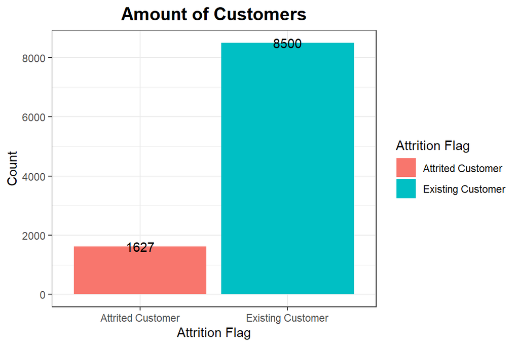

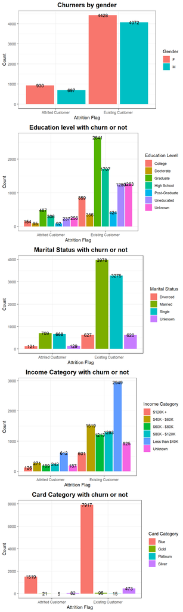

> For education level plot, we need to categorize college, doctorate, graduate and post-graduate to degree recipient. We notice that there are `unknown` variables on `Education level`, `Matrital status`, and `Income category`. So, we need to convert `Unknown` values to `NA` values.

### 2.1.1 Income relationship

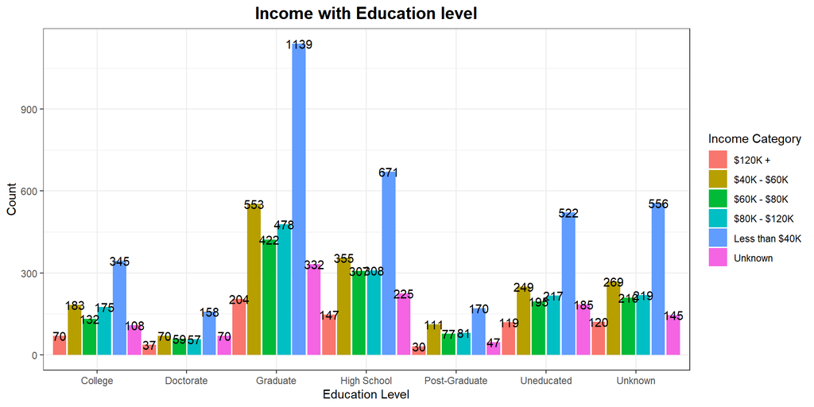

> In all education levels, `Less than $40k` shows a high percentage.

## 2.2 Numerical Variables

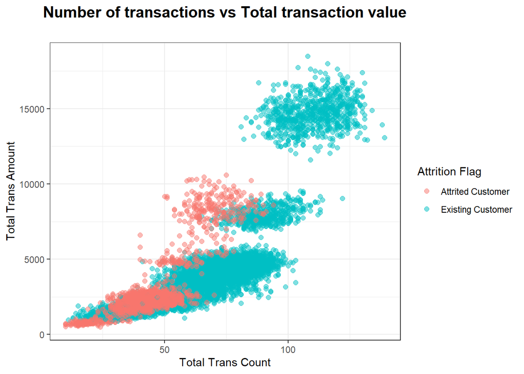

> The higher they spend annually, the customers are more likely to remain. The interesting part is that existing customers are divided into three clusters.

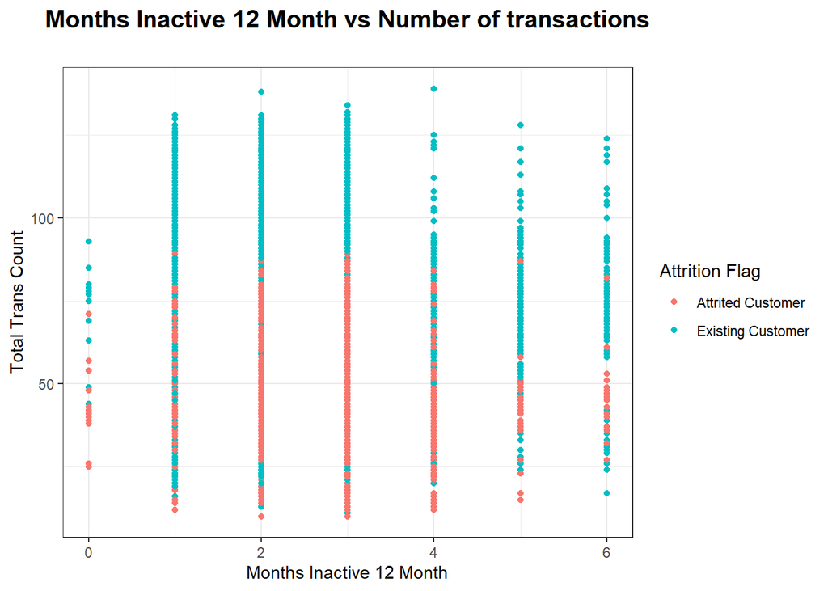

> After inactive of 2-3 month, customers are more likely to leave.

[figure not shown]

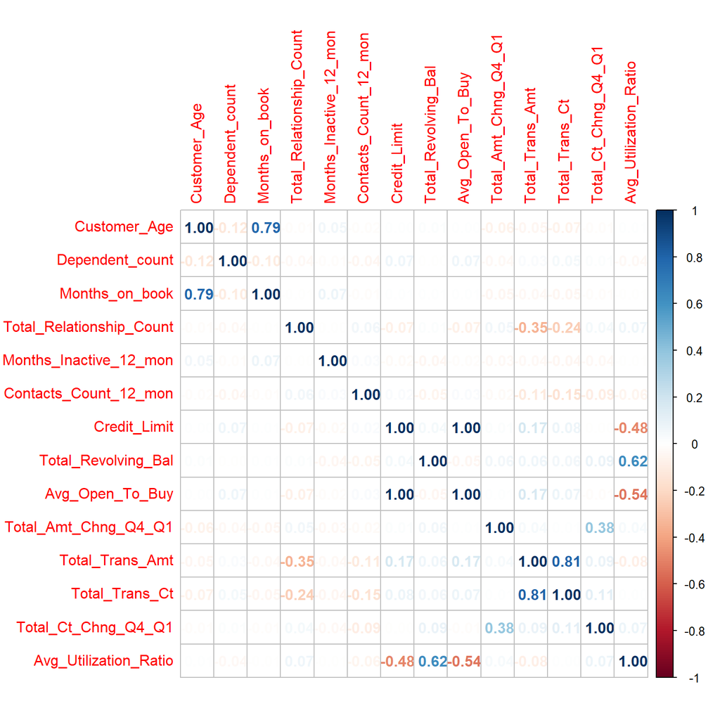

> `Credit_Limit` is correlated with `Avg_Open_To_Buy` and `Total_Trans_Amt` is correlated with `Total_Trans_Ct`, respectively. Correlated features will increase the complexity of the algorithm, thus increasing the risk of errors.

# 3 Data Preprocessing

```
## [1] TRUE
```

> There are no duplicate customer numbers

| **Characteristic** | **0**, N = 8,500<sup>1</sup> | **1**, N = 1,627<sup>1</sup> | **p-value**<sup>2</sup> |
| --- | --- | --- | --- |
| Education_Level |  |  | 0.6 |
| Degree recipient | 4,280 (50%) | 828 (51%) |  |
| High School | 1,707 (20%) | 306 (19%) |  |
| Uneducated | 1,250 (15%) | 237 (15%) |  |
| Unknown | 1,263 (15%) | 256 (16%) |  |
| Marital_Status |  |  | 0.11 |
| Divorced | 627 (7.4%) | 121 (7.4%) |  |
| Married | 3,978 (47%) | 709 (44%) |  |
| Single | 3,275 (39%) | 668 (41%) |  |
| Unknown | 620 (7.3%) | 129 (7.9%) |  |
| Income_Category |  |  | 0.025 |
| $120K + | 601 (7.1%) | 126 (7.7%) |  |
| $40K - $60K | 1,519 (18%) | 271 (17%) |  |
| $60K - $80K | 1,213 (14%) | 189 (12%) |  |
| $80K - $120K | 1,293 (15%) | 242 (15%) |  |
| Less than $40K | 2,949 (35%) | 612 (38%) |  |
| Unknown | 925 (11%) | 187 (11%) |  |
| Card_Category |  |  | 0.5 |
| Blue | 7,917 (93%) | 1,519 (93%) |  |
| Gold | 95 (1.1%) | 21 (1.3%) |  |
| Platinum | 15 (0.2%) | 5 (0.3%) |  |
| Silver | 473 (5.6%) | 82 (5.0%) |  |

<sup>1</sup> n (%)  
<sup>2</sup> Pearson’s Chi-squared test; Fisher’s exact test

> `Education_Level` p-value = 0.6, `Marital_Status` p-value = 0.11, `Income_Category` p-value = 0.025, `Card_Category` = 0.5

| **Characteristic** | **0**, N = 5,968<sup>1</sup> | **1**, N = 1,113<sup>1</sup> | **p-value**<sup>2</sup> |
| --- | --- | --- | --- |
| Education_Level |  |  | 0.2 |
| Degree recipient | 3,534 (59%) | 690 (62%) |  |
| High School | 1,416 (24%) | 237 (21%) |  |
| Uneducated | 1,018 (17%) | 186 (17%) |  |
| Marital_Status |  |  | 0.12 |
| Divorced | 477 (8.0%) | 92 (8.3%) |  |
| Married | 3,035 (51%) | 529 (48%) |  |
| Single | 2,456 (41%) | 492 (44%) |  |
| Income_Category |  |  | 0.015 |
| $120K + | 470 (7.9%) | 102 (9.2%) |  |
| $40K - $60K | 1,208 (20%) | 204 (18%) |  |
| $60K - $80K | 958 (16%) | 145 (13%) |  |
| $80K - $120K | 1,013 (17%) | 189 (17%) |  |
| Less than $40K | 2,319 (39%) | 473 (42%) |  |
| Card_Category |  |  | 0.7 |
| Blue | 5,564 (93%) | 1,034 (93%) |  |
| Gold | 68 (1.1%) | 13 (1.2%) |  |
| Platinum | 8 (0.1%) | 3 (0.3%) |  |
| Silver | 328 (5.5%) | 63 (5.7%) |  |

<sup>1</sup> n (%)  
<sup>2</sup> Pearson’s Chi-squared test; Fisher’s exact test

> `Education_Level` p-value = 0.2, `Marital_Status` p-value = 0.12, `Income_Category` p-value = 0.015, `Card_Category` = 0.7

> When comparing the p values from the two tables, the difference between the p-values of the columns with original data and the columns where the `NA` values are dropped is not large, and since the p values were meaningless in the first place, it is not a problem to drop them. Also, the `NA` values accounts for 30% of the whole data, but we have enough data to make models.

# 4 Modeling

## 4.1 Logistic Regression

### 4.1.1 Stepwise Logistic Regression

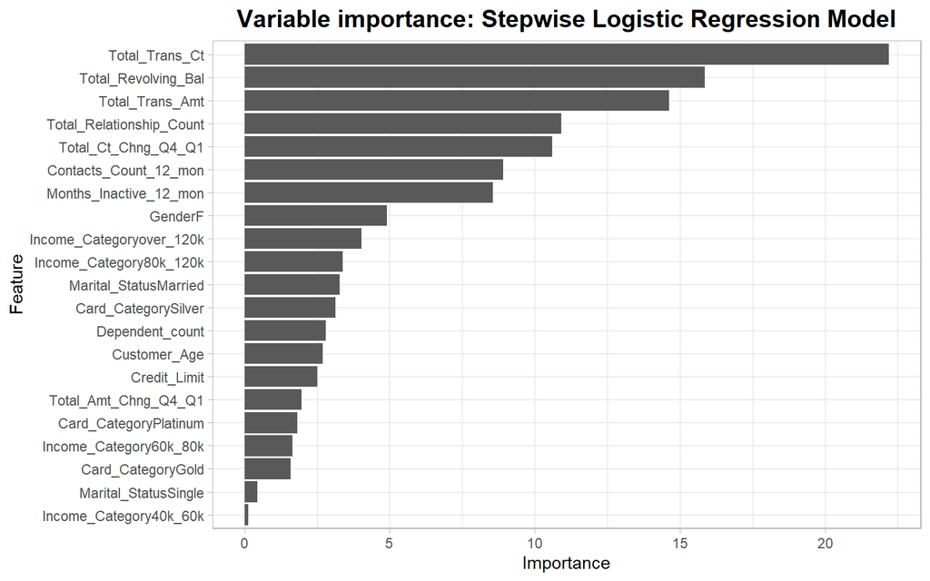

```
##
##        0    1
##   0 0.81 0.07
##   1 0.03 0.09
```

```
## Confusion Matrix and Statistics
##
##
##        0    1
##   0 1718  140
##   1   72  193
##
##                Accuracy : 0.9001
##                  95% CI : (0.8866, 0.9126)
##     No Information Rate : 0.8431
##     P-Value [Acc > NIR] : 1.372e-14
##
##                   Kappa : 0.5882
##
##  Mcnemar's Test P-Value : 4.193e-06
##
##             Sensitivity : 0.57958
##             Specificity : 0.95978
##          Pos Pred Value : 0.72830
##          Neg Pred Value : 0.92465
##              Prevalence : 0.15685
##          Detection Rate : 0.09091
##    Detection Prevalence : 0.12482
##       Balanced Accuracy : 0.76968
##
##        'Positive' Class : 1
##
```

### 4.1.2 Logistic Regression with k-fold cross-validation

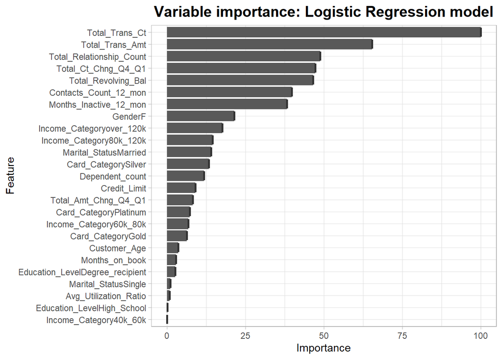

```
## Confusion Matrix and Statistics
##
##
##        0    1
##   0 1721  139
##   1   69  194
##
##                Accuracy : 0.902
##                  95% CI : (0.8886, 0.9143)
##     No Information Rate : 0.8431
##     P-Value [Acc > NIR] : 1.628e-15
##
##                   Kappa : 0.5949
##
##  Mcnemar's Test P-Value : 1.716e-06
##
##             Sensitivity : 0.58258
##             Specificity : 0.96145
##          Pos Pred Value : 0.73764
##          Neg Pred Value : 0.92527
##              Prevalence : 0.15685
##          Detection Rate : 0.09138
##    Detection Prevalence : 0.12388
##       Balanced Accuracy : 0.77202
##
##        'Positive' Class : 1
##
```

## 4.2 LASSO Regression

```
##   alpha lambda
## 5     1 0.0018
```

Tuning parameter ‘alpha’ was held constant at a value of 1 Accuracy was used to select the optimal model using the largest value. The final values used for the model were alpha = 1 and lambda = 0.0018.

```
## 26 x 1 sparse Matrix of class "dgCMatrix"
##                                     s1
## (Intercept)                      5.191
## Customer_Age                    -0.006
## GenderF                          0.618
## Dependent_count                  0.098
## Education_LevelHigh_School      -0.012
## Education_LevelDegree_recipient  0.065
## Marital_StatusMarried           -0.504
## Marital_StatusSingle             .
## Income_Category40k_60k          -0.068
## Income_Category60k_80k           .
## Income_Category80k_120k          0.301
## Income_Categoryover_120k         0.534
## Card_CategorySilver              0.488
## Card_CategoryGold                0.303
## Card_CategoryPlatinum            1.259
## Months_on_book                  -0.009
## Total_Relationship_Count        -0.400
## Months_Inactive_12_mon           0.429
## Contacts_Count_12_mon            0.408
## Credit_Limit                     0.000
## Total_Revolving_Bal             -0.001
## Total_Amt_Chng_Q4_Q1            -0.399
## Total_Trans_Amt                  0.000
## Total_Trans_Ct                  -0.103
## Total_Ct_Chng_Q4_Q1             -2.681
## Avg_Utilization_Ratio            .
```

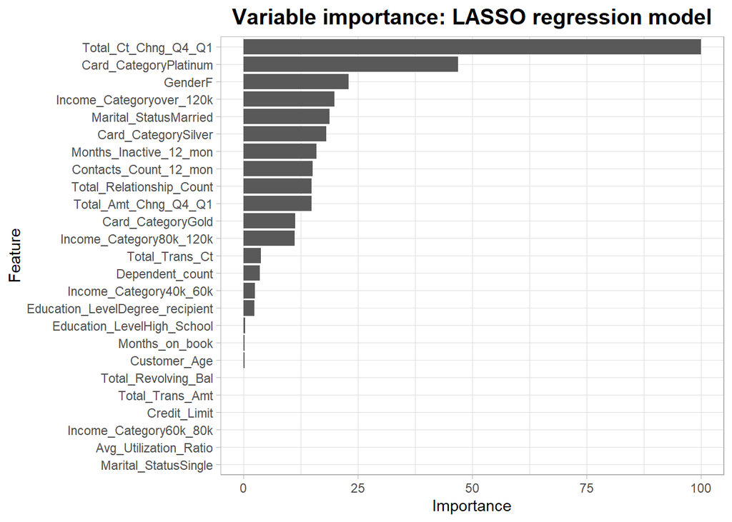

```
## Confusion Matrix and Statistics
##
##
##        0    1
##   0 1723  144
##   1   67  189
##
##                Accuracy : 0.9006
##                  95% CI : (0.8871, 0.913)
##     No Information Rate : 0.8431
##     P-Value [Acc > NIR] : 8.115e-15
##
##                   Kappa : 0.5852
##
##  Mcnemar's Test P-Value : 1.676e-07
##
##             Sensitivity : 0.56757
##             Specificity : 0.96257
##          Pos Pred Value : 0.73828
##          Neg Pred Value : 0.92287
##              Prevalence : 0.15685
##          Detection Rate : 0.08902
##    Detection Prevalence : 0.12058
##       Balanced Accuracy : 0.76507
##
##        'Positive' Class : 1
##
```

## 4.3 Decision tree

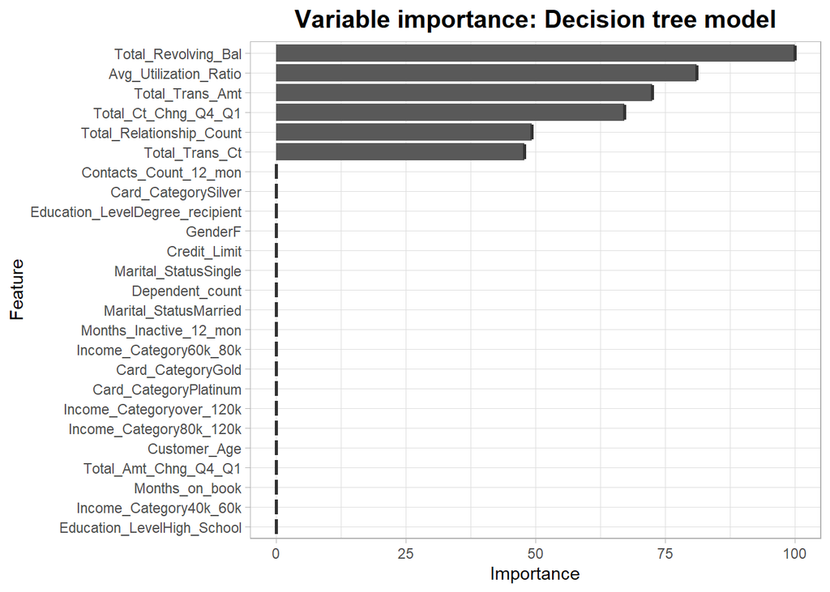

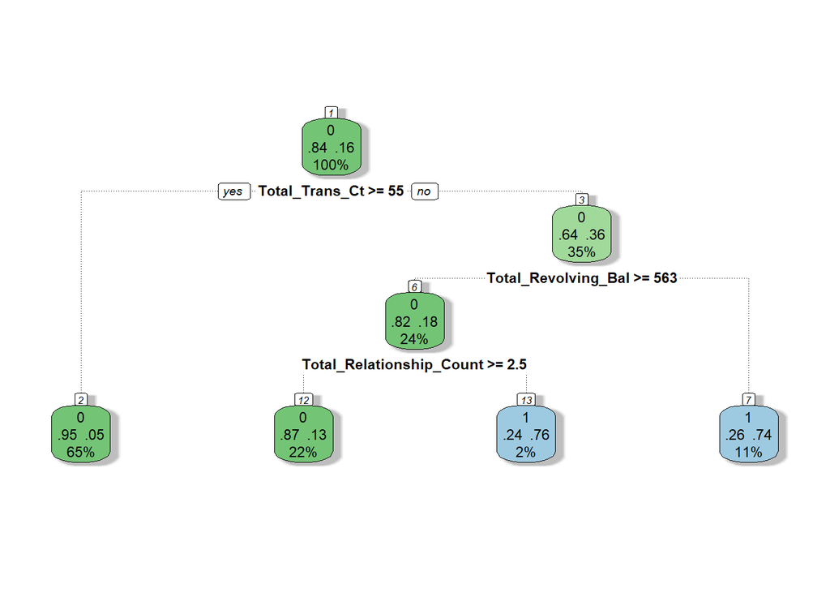

```
##
##        0    1
##   0 0.81 0.07
##   1 0.03 0.09
```

```
## Confusion Matrix and Statistics
##
##
##        0    1
##   0 1719  144
##   1   71  189
##
##                Accuracy : 0.8987
##                  95% CI : (0.8851, 0.9112)
##     No Information Rate : 0.8431
##     P-Value [Acc > NIR] : 6.424e-14
##
##                   Kappa : 0.5796
##
##  Mcnemar's Test P-Value : 9.091e-07
##
##             Sensitivity : 0.56757
##             Specificity : 0.96034
##          Pos Pred Value : 0.72692
##          Neg Pred Value : 0.92271
##              Prevalence : 0.15685
##          Detection Rate : 0.08902
##    Detection Prevalence : 0.12247
##       Balanced Accuracy : 0.76395
##
##        'Positive' Class : 1
##
```

## 4.4 Random forest

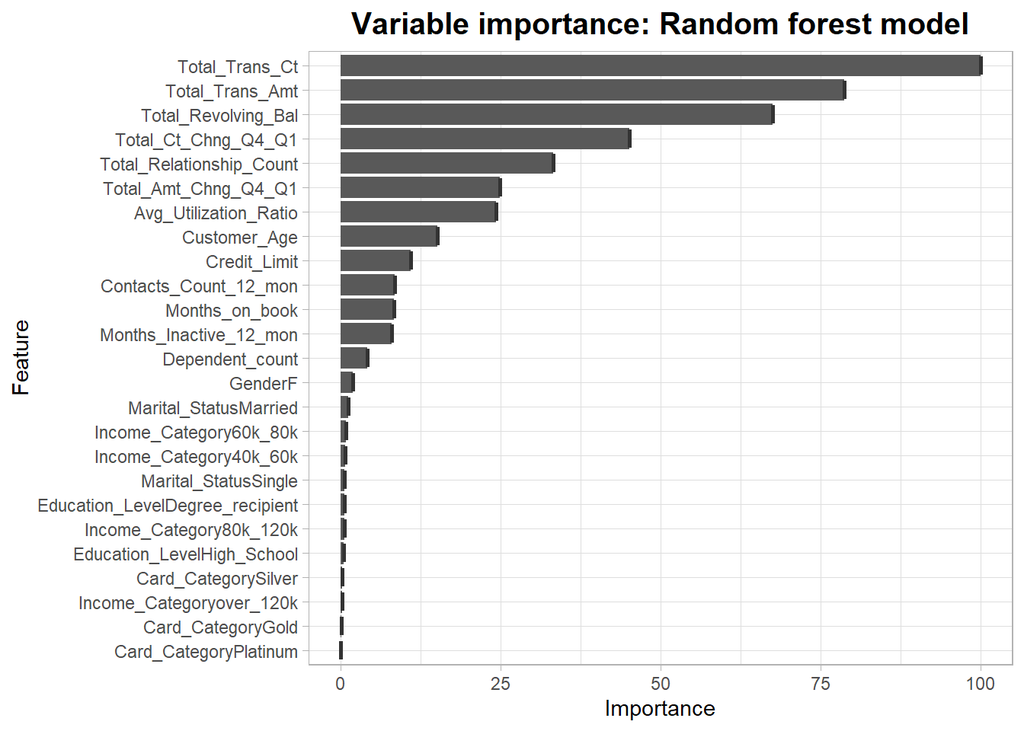

```
##
##        0    1
##   0 0.83 0.03
##   1 0.01 0.13
```

```
## Confusion Matrix and Statistics
##
##
##        0    1
##   0 1765   58
##   1   25  275
##
##                Accuracy : 0.9609
##                  95% CI : (0.9518, 0.9687)
##     No Information Rate : 0.8431
##     P-Value [Acc > NIR] : < 2.2e-16
##
##                   Kappa : 0.846
##
##  Mcnemar's Test P-Value : 0.000444
##
##             Sensitivity : 0.8258
##             Specificity : 0.9860
##          Pos Pred Value : 0.9167
##          Neg Pred Value : 0.9682
##              Prevalence : 0.1569
##          Detection Rate : 0.1295
##    Detection Prevalence : 0.1413
##       Balanced Accuracy : 0.9059
##
##        'Positive' Class : 1
##
```

## 4.5 Naive bayes

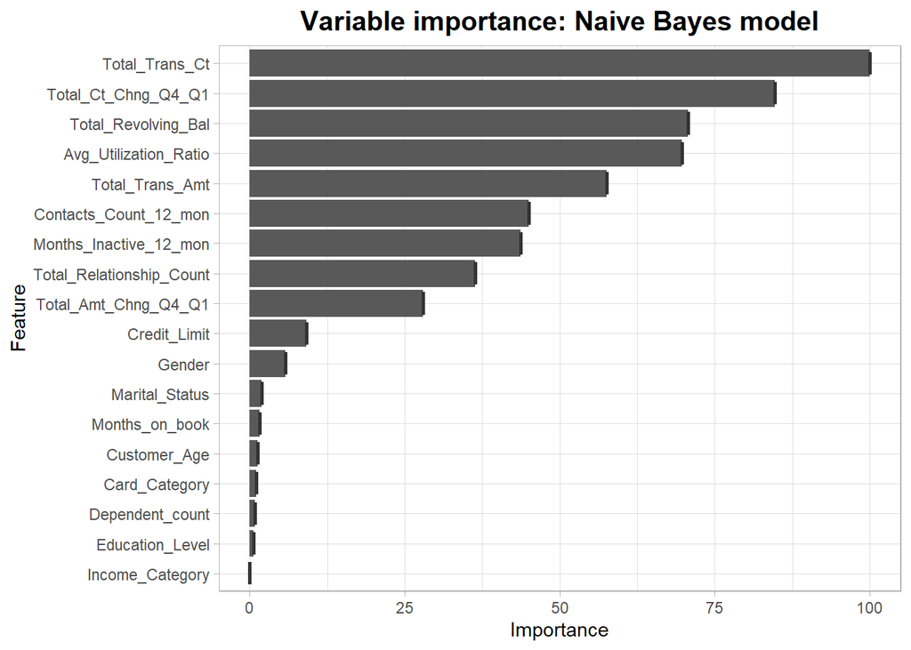

```
##
##        0    1
##   0 0.80 0.07
##   1 0.05 0.08
```

```
## Confusion Matrix and Statistics
##
##
##        0    1
##   0 1692  153
##   1   98  180
##
##                Accuracy : 0.8818
##                  95% CI : (0.8673, 0.8952)
##     No Information Rate : 0.8431
##     P-Value [Acc > NIR] : 2.341e-07
##
##                   Kappa : 0.5208
##
##  Mcnemar's Test P-Value : 0.0006533
##
##             Sensitivity : 0.54054
##             Specificity : 0.94525
##          Pos Pred Value : 0.64748
##          Neg Pred Value : 0.91707
##              Prevalence : 0.15685
##          Detection Rate : 0.08479
##    Detection Prevalence : 0.13095
##       Balanced Accuracy : 0.74290
##
##        'Positive' Class : 1
##
```

## 4.6 SVM

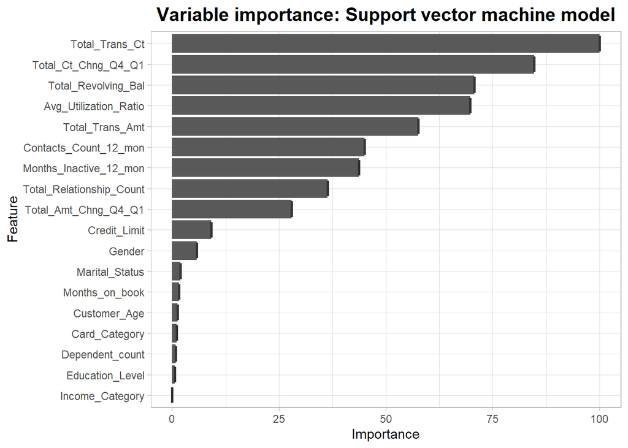

```
##
##        0    1
##   0 0.82 0.04
##   1 0.02 0.11
```

```
## Confusion Matrix and Statistics
##
##
##        0    1
##   0 1739   92
##   1   51  241
##
##                Accuracy : 0.9326
##                  95% CI : (0.9211, 0.9429)
##     No Information Rate : 0.8431
##     P-Value [Acc > NIR] : < 2.2e-16
##
##                   Kappa : 0.7319
##
##  Mcnemar's Test P-Value : 0.0008229
##
##             Sensitivity : 0.7237
##             Specificity : 0.9715
##          Pos Pred Value : 0.8253
##          Neg Pred Value : 0.9498
##              Prevalence : 0.1569
##          Detection Rate : 0.1135
##    Detection Prevalence : 0.1375
##       Balanced Accuracy : 0.8476
##
##        'Positive' Class : 1
##
```

```
##
##        0    1
##   0 0.82 0.04
##   1 0.02 0.11
```

## 4.7 k-NN

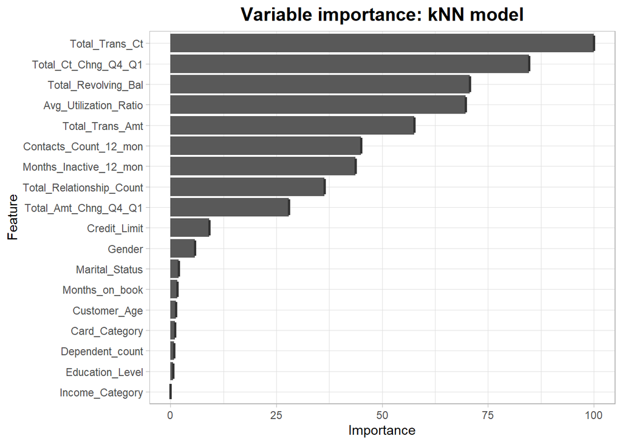

```
##
##        0    1
##   0 0.81 0.08
##   1 0.04 0.08
```

```
## Confusion Matrix and Statistics
##
##
##        0    1
##   0 1715  163
##   1   75  170
##
##                Accuracy : 0.8879
##                  95% CI : (0.8737, 0.901)
##     No Information Rate : 0.8431
##     P-Value [Acc > NIR] : 2.018e-09
##
##                   Kappa : 0.5251
##
##  Mcnemar's Test P-Value : 1.707e-08
##
##             Sensitivity : 0.51051
##             Specificity : 0.95810
##          Pos Pred Value : 0.69388
##          Neg Pred Value : 0.91321
##              Prevalence : 0.15685
##          Detection Rate : 0.08008
##    Detection Prevalence : 0.11540
##       Balanced Accuracy : 0.73431
##
##        'Positive' Class : 1
##
```

# 5. Summary

## 5.1 ROC curves and AUC values

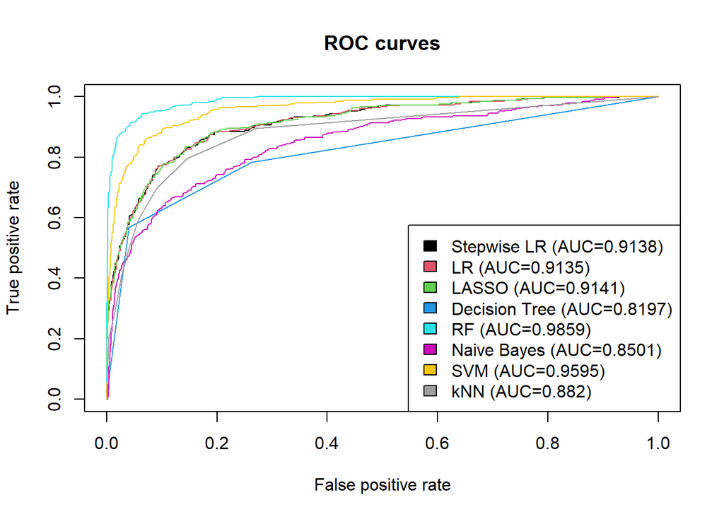

## 5.2 Results

| Method | AUC | Accuracy | Kappa | Sensitivity | Specificity | F1_score |
| --- | --- | --- | --- | --- | --- | --- |
| Stepwise Logistic Regression | 0.9138 | 0.9001 | 0.5882 | 0.5796 | 0.9598 | 0.6455 |
| Logistic Regression with k-fold cv | 0.9135 | 0.9020 | 0.5949 | 0.5826 | 0.9614 | 0.6510 |
| LASSO Regression | 0.9141 | 0.9006 | 0.5852 | 0.5676 | 0.9626 | 0.6418 |
| Decision Tree | 0.8197 | 0.8987 | 0.5796 | 0.5676 | 0.9603 | 0.6374 |
| Random Forest | 0.9859 | 0.9609 | 0.8460 | 0.8258 | 0.9860 | 0.8689 |
| Naive Bayes | 0.8501 | 0.8818 | 0.5208 | 0.5405 | 0.9452 | 0.5892 |
| SVM | 0.9595 | 0.9326 | 0.7319 | 0.7237 | 0.9715 | 0.7712 |
| k-NN | 0.8820 | 0.8879 | 0.5251 | 0.5105 | 0.9581 | 0.5882 |

> This is a summary of our prediction models. Random Forest has best model compared to other with metrics score(Kappa, Sensitivity, Specificity and F1 score) has shown at least 96% accuracy. Random Forest have AUC score of 98% that shows the model is learning the data well enough.